# Reading Data: Databases and SQL

## Databases and SQL

Structured Query Language (SQL - pronounced ess-que-el or sequel) - language used by relational database management systems (RDBMS)

- Used to obtain data from tables (rectangular data sets)
- Used to combine data from separate tables
- Tables have 'keys' that relate them
- Manipulate and create variables
- Structure and edit databases

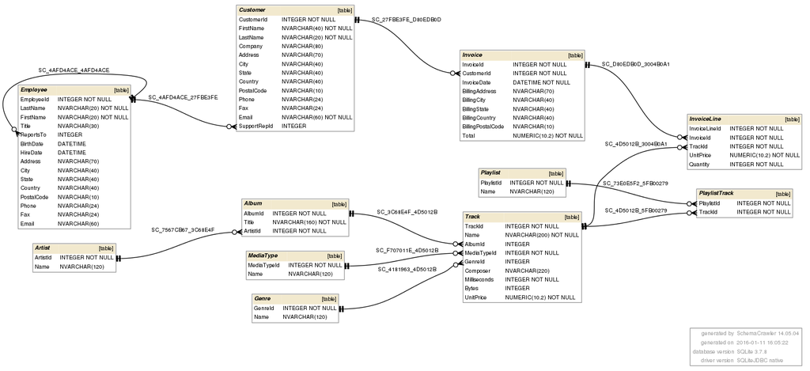

Source: https://blog.stefanproell.at/wp-content/uploads/2016/01/ER.png

## Databases and SQL

`Lahman` package contained tables with keys

- The main form of this database is a relational database in Microsoft Access format. The design follows these general principles: Each player is assigned a unique code (playerID). All of the information in different tables relating to that player is tagged with his playerID. The playerIDs are linked to names and birthdates in the Master table. Similar links exist among other tables via analogous *ID variables.
- The database is composed of the following main tables:  
  Master  
  Player names, dates of birth, death and other biographical info  
  Batting  
  batting statistics

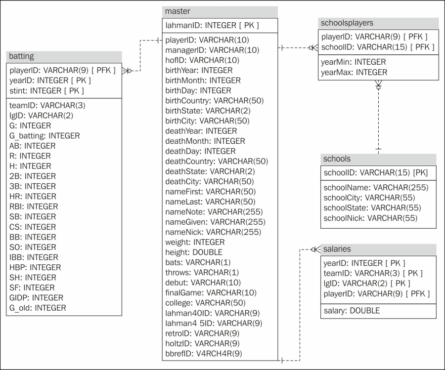

Source: https://www.oreilly.com/library/view/pentaho-data-integration/9781783280674/apas05.html

## Databases and SQL

Structured Query Language (SQL - pronounced ess-que-el or sequel) - language used by relational database management systems (RDBMS)

- Database Manipulation Language (DML) - basic commands similar to our comon `dplyr` commands (`select()`, `filter()`, etc.)
- Database Definition Language (DDL) - structure objects in a database (create a new table for instance)
- Database Control Language (DCL) - administration of databases (we won't cover any of this)

## Databases and SQL

Structured Query Language (SQL - pronounced ess-que-el or sequel) - language used by relational database management systems (RDBMS)

- Many popular RDBMS, some free some proprietary (often referred to as databases…)
- Oracle - most popular (cross platform)
- SQL Server - Microsoft product
- DB2 - IBM product
- MySQL (open source) - Not as many features but popular
- PostgreSQL (open source)

[Basic language](http://www.sqltutorial.org/sql-cheat-sheet/) constant across all - features differ

## Databases: Common flow in R

1. Connect to the database
- `DBI` package, `dbConnect()` function
- 1st arg to `dbConnect()` is database backend (need appropriate R package)
  - `RSQLite::SQLite()` for RSQLite
  - `RMySQL::MySQL()` for RMySQL
  - `RPostgreSQL::PostgreSQL()` for RPostgreSQL
  - `odbc::odbc()` for Open Database Connectivity
  - `bigrquery::bigquery()` for google's bigQuery

```r
con <- DBI::dbConnect(RMySQL::MySQL(),
  host = "hostname.website",
  user = "username",
  password = rstudioapi::askForPassword("DB password")
)
```

## Databases: Common flow in R

1. Connect to the database
- `DBI` package, `dbConnect()` function
- 1st arg to `dbConnect()` is database backend (need appropriate R package)
2. Use `tbl()` to reference a table in the database

```r
new_data <- tbl(con, "name_of_table")
```

## Databases: Common flow in R

1. Connect to the database
- `DBI` package, `dbConnect()` function
- 1st arg to `dbConnect()` is database backend (need appropriate R package)
2. Use `tbl()` to reference a table in the database
3. Query the database with `SQL` or `dplyr/dbplyr`
- `dplyr` verbs will get you pretty far without needing to know `SQL` or `dbplyr`

## Databases and SQL

Create a database in RStudio

```r
#install.packages("RSQLite")
library(RSQLite)
my_db_file <- "lahman.sqlite"
my_db <- src_sqlite(my_db_file, create = TRUE)
my_db
```

```
## src:  sqlite 3.22.0 [C:\Users\jbpost2\Documents\Repos\ST-558\5_DataSources\lahman.sqlite]
## tbls:
```

## Databases and SQL

Add tables to the database

```r
library(Lahman)
copy_to(my_db, Master)
copy_to(my_db, Pitching)
copy_to(my_db, Fielding)
copy_to(my_db, Batting)
copy_to(my_db, AwardsPlayers)
copy_to(my_db, AwardsSharePlayers)
my_db
```

```
## src:  sqlite 3.22.0 [C:\Users\jbpost2\Documents\Repos\ST-558\5_DataSources\lahman.sqlite]
## tbls: AwardsPlayers, AwardsSharePlayers, Batting, Fielding, Master,
##   Pitching, sqlite_stat1, sqlite_stat4
```

## Databases and SQL

Can use basic `dplyr` code to produce `SQL` queries

```r
tbl(my_db, "Pitching") %>% select(ends_with("ID")) %>%
    filter(yearID == 2010) %>% show_query()
```

`<SQL>`  
`SELECT *`  
`FROM (SELECT 'playerID', 'yearID', 'teamID', 'lgID'`  
`FROM 'Pitching')`  
`WHERE ('yearID' = 2010.0)`

## Databases and SQL

Notice number of rows!

```r
temp <- tbl(my_db, "Pitching") %>% select(ends_with("ID")) %>%
    filter(yearID == 2010)
temp
```

```
## # Source:   lazy query [?? x 4]
## # Database: sqlite 3.22.0
## #   [C:\Users\jbpost2\Documents\Repos\ST-558\5_DataSources\lahman.sqlite]
##   playerID  yearID teamID lgID
##   <chr>      <int> <chr>  <chr>
## 1 aardsda01   2010 SEA    AL
## 2 abadfe01    2010 HOU    NL
## 3 accarje01   2010 TOR    AL
## 4 aceveal01   2010 NYA    AL
## 5 acostma01   2010 NYN    NL
## # ... with more rows
```

## Databases and SQL

How `dplry` works with a database

- It never pulls data into R unless you explicitly ask for it
- It delays doing any work until the last possible moment - it collects together everything you want to do and then sends it to the database in one step

## Databases and SQL

`collect()` will return everything from the query

```r
temp <- tbl(my_db, "Pitching") %>% select(ends_with("ID")) %>%
    filter(yearID == 2010) %>% collect()
temp
```

```
## # A tibble: 684 x 4
##   playerID  yearID teamID lgID
##   <chr>      <int> <chr>  <chr>
## 1 aardsda01   2010 SEA    AL
## 2 abadfe01    2010 HOU    NL
## 3 accarje01   2010 TOR    AL
## 4 aceveal01   2010 NYA    AL
## 5 acostma01   2010 NYN    NL
## # ... with 679 more rows
```

## Databases and SQL

- `dplyr` does not give super 'readable' `SQL` code necessarily

```
## <SQL>
## SELECT *
## FROM (SELECT `playerID`, `yearID`, `teamID`, `lgID`
## FROM `Pitching`)
## WHERE (`yearID` = 2010.0)
```

```r
tbl(my_db, sql(
"SELECT `playerID`, `yearID`, `teamID`, `lgID`
        FROM `Pitching`
WHERE (`yearID` = 2010.0)")) %>% collect()
```

```
## # A tibble: 684 x 4
##   playerID  yearID teamID lgID
##   <chr>      <int> <chr>  <chr>
## 1 aardsda01   2010 SEA    AL
## 2 abadfe01    2010 HOU    NL
## 3 accarje01   2010 TOR    AL
## 4 aceveal01   2010 NYA    AL
## 5 acostma01   2010 NYN    NL
## # ... with 679 more rows
```

## Databases and SQL

Ton of online tutorials to learn SQL

- Highly recommended if you are looking for a job
- *Joins* very important- methods to combine more than one table (data frame)

## Databases and SQL

Ton of online tutorials to learn SQL

- Highly recommended if you are looking for a job
- *Joins* very important - methods to combine more than one table (data frame)
- We'll learn `dplyr` joins
- `dplyr` functions and joins basically gives you all the logic needed to do SQL
- Just need to learn SQL syntax (can start by using `show_query()`!)

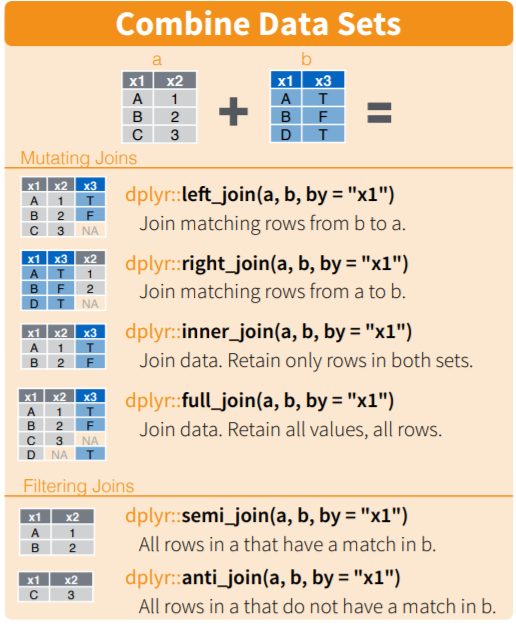

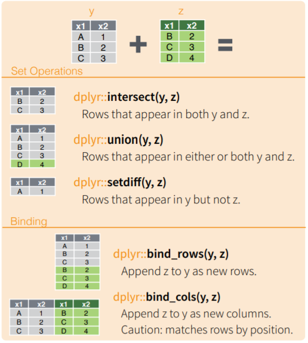

## Joins

- May want to combine two data sets: `left_join()`, `right_join()`, `inner_join()`, `full_join()`

(Cite: http://rpubs.com/justmarkham/dplyr-tutorial-part-2)

```r
# create two simple data frames
a <- data_frame(color = c("green", "yellow", "red"), num = 1:3)
b <- data_frame(color = c("green", "yellow", "pink"), size = c("S", "M", "L"))
```

```r
a
```

```
## # A tibble: 3 x 2
##   color    num
##   <chr>  <int>
## 1 green      1
## 2 yellow     2
## 3 red        3
```

```r
b
```

```
## # A tibble: 3 x 2
##   color  size
##   <chr>  <chr>
## 1 green  S
## 2 yellow M
## 3 pink   L
```

## Subsetting/Manipulating Data

`left_join()`, `right_join()`, `inner_join()`, `full_join()` - combine multiple DFs

- Only include observations found in both "a" and "b" (automatically joins on variables that appear in both tables)

```r
a
```

```
## # A tibble: 3 x 2
##   color    num
##   <chr>  <int>
## 1 green      1
## 2 yellow     2
## 3 red        3
```

```r
b
```

```
## # A tibble: 3 x 2
##   color  size
##   <chr>  <chr>
## 1 green  S
## 2 yellow M
## 3 pink   L
```

```r
inner_join(a, b)
```

```
## # A tibble: 2 x 3
##   color    num size
##   <chr>  <int> <chr>
## 1 green      1 S
## 2 yellow     2 M
```

## Subsetting/Manipulating Data

`left_join()`, `right_join()`, `inner_join()`, `full_join()` - combine multiple DFs

- include observations found in either "a" or "b"

```r
a
```

```
## # A tibble: 3 x 2
##   color    num
##   <chr>  <int>
## 1 green      1
## 2 yellow     2
## 3 red        3
```

```r
b
```

```
## # A tibble: 3 x 2
##   color  size
##   <chr>  <chr>
## 1 green  S
## 2 yellow M
## 3 pink   L
```

```r
full_join(a, b)
```

```
## # A tibble: 4 x 3
##   color    num size
##   <chr>  <int> <chr>
## 1 green      1 S
## 2 yellow     2 M
## 3 red        3 <NA>
## 4 pink      NA L
```

## Subsetting/Manipulating Data

`left_join()`, `right_join()`, `inner_join()`, `full_join()` - combine multiple DFs

- include all observations found in "a", match with b

```r
a
```

```
## # A tibble: 3 x 2
##   color    num
##   <chr>  <int>
## 1 green      1
## 2 yellow     2
## 3 red        3
```

```r
b
```

```
## # A tibble: 3 x 2
##   color  size
##   <chr>  <chr>
## 1 green  S
## 2 yellow M
## 3 pink   L
```

```r
left_join(a, b)
```

```
## # A tibble: 3 x 3
##   color    num size
##   <chr>  <int> <chr>
## 1 green      1 S
## 2 yellow     2 M
## 3 red        3 <NA>
```

## Subsetting/Manipulating Data

`left_join()`, `right_join()`, `inner_join()`, `full_join()` - combine multiple DFs

- include all observations found in "b", match with a

```r
a
```

```
## # A tibble: 3 x 2
##   color    num
##   <chr>  <int>
## 1 green      1
## 2 yellow     2
## 3 red        3
```

```r
b
```

```
## # A tibble: 3 x 2
##   color  size
##   <chr>  <chr>
## 1 green  S
## 2 yellow M
## 3 pink   L
```

```r
right_join(a, b)
```

```
## # A tibble: 3 x 3
##   color    num size
##   <chr>  <int> <chr>
## 1 green      1 S
## 2 yellow     2 M
## 3 pink      NA L
```

## Subsetting/Manipulating Data

`left_join()`, `right_join()`, `inner_join()`, `full_join()` - combine multiple DFs

- `right_join(a, b)` is identical to `left_join(b, a)` except for column ordering

```r
right_join(a,b)
```

```
## # A tibble: 3 x 3
##   color    num size
##   <chr>  <int> <chr>
## 1 green      1 S
## 2 yellow     2 M
## 3 pink      NA L
```

```r
left_join(b, a)
```

```
## # A tibble: 3 x 3
##   color  size    num
##   <chr>  <chr> <int>
## 1 green  S         1
## 2 yellow M         2
## 3 pink   L        NA
```

## Subsetting/Manipulating Data

`left_join()`, `right_join()`, `inner_join()`, `full_join()` - combine multiple DFs

- filter "a" to only show observations that match "b"

```r
a
```

```
## # A tibble: 3 x 2
##   color    num
##   <chr>  <int>
## 1 green      1
## 2 yellow     2
## 3 red        3
```

```r
b
```

```
## # A tibble: 3 x 2
##   color  size
##   <chr>  <chr>
## 1 green  S
## 2 yellow M
## 3 pink   L
```

```r
semi_join(a, b)
```

```
## # A tibble: 2 x 2
##   color    num
##   <chr>  <int>
## 1 green      1
## 2 yellow     2
```

## Subsetting/Manipulating Data

`left_join()`, `right_join()`, `inner_join()`, `full_join()` - combine multiple DFs

- filter "a" to only show observations that don't match "b"

```r
a
```

```
## # A tibble: 3 x 2
##   color    num
##   <chr>  <int>
## 1 green      1
## 2 yellow     2
## 3 red        3
```

```r
b
```

```
## # A tibble: 3 x 2
##   color  size
##   <chr>  <chr>
## 1 green  S
## 2 yellow M
## 3 pink   L
```

```r
anti_join(a, b)
```

```
## # A tibble: 1 x 2
##   color   num
##   <chr> <int>
## 1 red       3
```

## Subsetting/Manipulating Data

`left_join()`, `right_join()`, `inner_join()`, `full_join()` - combine multiple DFs

- sometimes matching variables don't have identical names

```r
b <- b %>% rename(col = color)
a
```

```
## # A tibble: 3 x 2
##   color    num
##   <chr>  <int>
## 1 green      1
## 2 yellow     2
## 3 red        3
```

```r
b
```

```
## # A tibble: 3 x 2
##   col    size
##   <chr>  <chr>
## 1 green  S
## 2 yellow M
## 3 pink   L
```

## Subsetting/Manipulating Data

`left_join()`, `right_join()`, `inner_join()`, `full_join()` - combine multiple DFs

- specify that the join should occur by matching "color" in "a" with "col" in "b"

```r
a
```

```
## # A tibble: 3 x 2
##   color    num
##   <chr>  <int>
## 1 green      1
## 2 yellow     2
## 3 red        3
```

```r
b
```

```
## # A tibble: 3 x 2
##   col    size
##   <chr>  <chr>
## 1 green  S
## 2 yellow M
## 3 pink   L
```

```r
inner_join(a, b,
    by = c("color" = "col"))
```

```
## # A tibble: 2 x 3
##   color    num size
##   <chr>  <int> <chr>
## 1 green      1 S
## 2 yellow     2 M
```

## Subsetting/Manipulating Data

`dplyr` code:

```r
inner_join(select(tbl(my_db, "Pitching"), "playerID", "yearID", "W"),
             select(tbl(my_db, "AwardsPlayers"), "playerID", "yearID", "awardID")) %>%
  filter(yearID > 2010) %>% collect()
```

```
## # A tibble: 78 x 4
##   playerID  yearID     W awardID
##   <chr>      <int> <int> <chr>
## 1 axforjo01   2011     2 Rolaids Relief Man Award
## 2 buehrma01   2011    13 Gold Glove
## 3 hellije01   2011    13 Rookie of the Year
## 4 hudsoda01   2011    16 Silver Slugger
## 5 kershcl01   2011    21 Cy Young Award
## # ... with 73 more rows
```

## Subsetting/Manipulating Data

`SQL` code:

```r
inner_join(select(tbl(my_db, "Pitching"), "playerID", "yearID", "W"),
             select(tbl(my_db, "AwardsPlayers"), "playerID", "yearID", "awardID")) %>%
  filter(yearID > 2010) %>% show_query()
```

```
## <SQL>
## SELECT *
## FROM (SELECT `LHS`.`playerID` AS `playerID`, `LHS`.`yearID` AS `yearID`, `LHS`.`W` AS `W`, `RHS`.`awardID` AS `awardID`
## FROM (SELECT `playerID`, `yearID`, `W`
## FROM `Pitching`) AS `LHS`
## INNER JOIN (SELECT `playerID`, `yearID`, `awardID`
## FROM `AwardsPlayers`) AS `RHS`
## ON (`LHS`.`playerID` = `RHS`.`playerID` AND `LHS`.`yearID` = `RHS`.`yearID`)
## )
## WHERE (`yearID` > 2010.0)
```

## Subsetting/Manipulating Data

```r
tbl(my_db, sql(
"SELECT `LHS`.`playerID` AS `playerID`, `LHS`.`yearID` AS `yearID`, `LHS`.`W` AS `W`, `RHS`.`awardID` AS `awardID`
FROM (SELECT `playerID`, `yearID`, `W`
               FROM `Pitching`) AS `LHS`
INNER JOIN (SELECT `playerID`, `yearID`, `awardID`
               FROM `AwardsPlayers`) AS `RHS`
ON (`LHS`.`playerID` = `RHS`.`playerID` AND `LHS`.`yearID` = `RHS`.`yearID`)")) %>% collect()
```

```
## # A tibble: 1,659 x 4
##   playerID  yearID     W awardID
##   <chr>      <int> <int> <chr>
## 1 bondto01    1877    40 Pitching Triple Crown
## 2 heckegu01   1884    52 Pitching Triple Crown
## 3 radboch01   1884    59 Pitching Triple Crown
## 4 keefeti01   1888    35 Pitching Triple Crown
## 5 clarkjo01   1889    49 Pitching Triple Crown
## # ... with 1,654 more rows
```

## Overview of `dplyr` package [cheatsheet](https://www.rstudio.com/wp-content/uploads/2015/02/data-wrangling-cheatsheet.pdf)

- Basic commands
  - `tbl_df()` - convert data frame to one with better printing
  - `filter()` - subset **rows**
  - `arrange()` - reorder **rows**
  - `select()` - subset **columns**
  - `mutate()` - add newly created **column**
  - `transmute()` - create new variable
  - `group_by()` - group **rows** by a variable
  - `summarise()` - apply basic function to data
  - `left_join()`, `right_join()`, `inner_join()`, `full_join()` - commands to combine multiple data frames